# Scientifc Python

In this section, we learn some basic scientific functions and packages. We use the [NumPy](http://www.numpy.org/), [SciPy](https://www.scipy.org/), [Matplotlib](https://matplotlib.org/), [Interpolation](https://github.com/econforge/interpolation.py), [AstroPy](http://www.astropy.org/) and [SunPy](http://sunpy.org/) packages.

**Required packages**

> - [Python](http://www.python.org) v2.7 or 3.5 or 3.6
> - [NumPy](http://www.numpy.org/) v1.7+
> - [SciPy](https://www.scipy.org/) v1.0+
> - [Matplotlib](https://matplotlib.org/) v2.0+
> - [AstroPy](http://www.astropy.org/) v2.0+

[figure not shown]

> - [SunPy](http://sunpy.org/) v0.8+ (Warning ! : This package is developing package, so that some of functions can be depricated)

[figure not shown]

> - [Interpolation](https://github.com/econforge/interpolation.py) v0.18+

Above requried packages can be downloaded by using conda command in your cmd prompt or terminal as below :

```
conda install -c condaforge sunpy astropy interpolation
```

This tutorial is based on the [Scipy-Lecture notes](http://www.scipy-lectures.org).

**You can download this tutorial file on the [fisspy-tutorials](https://github.com/SNU-sunday/fisspy-tutorials/tree/master/tutorials/scientific_python.ipynb) Github site below**

https://github.com/SNU-sunday/fisspy-tutorials/tree/master/tutorials/scientific_python.ipynb

and some examples files.

# 1. Compatibility

Some of calling syntaxes are differen according to python version. The main differences are print statement and division operator. In python 2, division operator '**/**' is the floor division, but in python3 it isn't the floor division. In python3 floor division syntax is '**//**' To avoid this compatibility problem, we import the "**future**" method.

```python
from __future__ import division, print_function
```

# 2. The NumPy array

To call arrays in python, we have to import the **numpy** package at first.

```python
import numpy as np
```

## 2.1. Manual construction of arrays

```python
a = np.array([1,5,2,4,3,0])
a
```

```
array([1, 5, 2, 4, 3, 0])
```

This array can be sort by using **sort** function

```python
a.sort()
a
```

```
array([0, 1, 2, 3, 4, 5])
```

```python
a.dtype
```

```
dtype('int32')
```

```python
b = np.array([[0,1,2],[3,4,5]],dtype = 'float')
b
```

```
array([[ 0.,  1.,  2.],
       [ 3.,  4.,  5.]])
```

```python
b.dtype
```

```
dtype('float64')
```

```python
b.shape          # Same with the size function in IDL
```

```
(2, 3)
```

```python
len(b)           # returns the size of the first dimension
```

```
2
```

convert row array to column array

```python
c = a[:,None]
c
```

```
array([[0],
       [1],
       [2],
       [3],
       [4],
       [5]])
```

## 2.2 Functions for creating arrays

```python
a = np.arange(6)   # similar with the *indgen functions in IDL
a
```

```
array([0, 1, 2, 3, 4, 5])
```

```python
b = np.arange(0,10,0.1)
b
```

```
array([ 0. ,  0.1,  0.2,  0.3,  0.4,  0.5,  0.6,  0.7,  0.8,  0.9,  1. ,
        1.1,  1.2,  1.3,  1.4,  1.5,  1.6,  1.7,  1.8,  1.9,  2. ,  2.1,
        2.2,  2.3,  2.4,  2.5,  2.6,  2.7,  2.8,  2.9,  3. ,  3.1,  3.2,
        3.3,  3.4,  3.5,  3.6,  3.7,  3.8,  3.9,  4. ,  4.1,  4.2,  4.3,
        4.4,  4.5,  4.6,  4.7,  4.8,  4.9,  5. ,  5.1,  5.2,  5.3,  5.4,
        5.5,  5.6,  5.7,  5.8,  5.9,  6. ,  6.1,  6.2,  6.3,  6.4,  6.5,
        6.6,  6.7,  6.8,  6.9,  7. ,  7.1,  7.2,  7.3,  7.4,  7.5,  7.6,
        7.7,  7.8,  7.9,  8. ,  8.1,  8.2,  8.3,  8.4,  8.5,  8.6,  8.7,
        8.8,  8.9,  9. ,  9.1,  9.2,  9.3,  9.4,  9.5,  9.6,  9.7,  9.8,
        9.9])
```

```python
np.arange?
```

```python
c = np.linspace(0,10,101)
c
```

```
array([  0. ,   0.1,   0.2,   0.3,   0.4,   0.5,   0.6,   0.7,   0.8,
         0.9,   1. ,   1.1,   1.2,   1.3,   1.4,   1.5,   1.6,   1.7,
         1.8,   1.9,   2. ,   2.1,   2.2,   2.3,   2.4,   2.5,   2.6,
         2.7,   2.8,   2.9,   3. ,   3.1,   3.2,   3.3,   3.4,   3.5,
         3.6,   3.7,   3.8,   3.9,   4. ,   4.1,   4.2,   4.3,   4.4,
         4.5,   4.6,   4.7,   4.8,   4.9,   5. ,   5.1,   5.2,   5.3,
         5.4,   5.5,   5.6,   5.7,   5.8,   5.9,   6. ,   6.1,   6.2,
         6.3,   6.4,   6.5,   6.6,   6.7,   6.8,   6.9,   7. ,   7.1,
         7.2,   7.3,   7.4,   7.5,   7.6,   7.7,   7.8,   7.9,   8. ,
         8.1,   8.2,   8.3,   8.4,   8.5,   8.6,   8.7,   8.8,   8.9,
         9. ,   9.1,   9.2,   9.3,   9.4,   9.5,   9.6,   9.7,   9.8,
         9.9,  10. ])
```

```python
np.linspace?
```

```python
one = np.ones((3,3))
```

```python
one
```

```
array([[ 1.,  1.,  1.],
       [ 1.,  1.,  1.],
       [ 1.,  1.,  1.]])
```

```python
zero = np.zeros((2,3))
```

```python
zero
```

```
array([[ 0.,  0.,  0.],
       [ 0.,  0.,  0.]])
```

```python
np.random.seed(2018)
```

```python
randu = np.random.rand(4)   #uniform random number generator
randu
```

```
array([ 0.88234931,  0.10432774,  0.90700933,  0.3063989 ])
```

```python
randg = np.random.randn(5) #gaussian random number generator
randg
```

```
array([ 2.14839926, -1.279487  ,  0.50227689,  0.8560293 , -0.14279008])
```

#### Exercise 1) Create an array which has equaily spaced elements from 5 to 100 with step size = 5 .

#### Exercise 2) Create an array which has 100 equaily spaced elements from 0 to 2

## 2.3. Indexing and slicing

```python
a = np.arange(10)
```

```python
a[0]
```

```
0
```

```python
a[:]
```

```
array([0, 1, 2, 3, 4, 5, 6, 7, 8, 9])
```

```python
a[3:6]
```

```
array([3, 4, 5])
```

```python
a[3:8:2]
```

```
array([3, 5, 7])
```

```python
a[3:]
```

```
array([3, 4, 5, 6, 7, 8, 9])
```

#### Array reshaping

```python
d=np.arange(25)
```

```python
d = d.reshape((5,5))
```

```python
d
```

```
array([[ 0,  1,  2,  3,  4],
       [ 5,  6,  7,  8,  9],
       [10, 11, 12, 13, 14],
       [15, 16, 17, 18, 19],
       [20, 21, 22, 23, 24]])
```

```python
d[3]
```

```
array([15, 16, 17, 18, 19])
```

```python
d[:,3]
```

```
array([ 3,  8, 13, 18, 23])
```

```python
b = d.transpose()
```

```python
b[3]
```

```
array([ 3,  8, 13, 18, 23])
```

```python
d[:2]
```

```
array([[0, 1, 2, 3, 4],
       [5, 6, 7, 8, 9]])
```

## 2.4. Broadcasting

```python
a = np.arange(5)
```

```python
b = np.ones(5, dtype=int)
```

```python
a
```

```
array([0, 1, 2, 3, 4])
```

```python
b
```

```
array([1, 1, 1, 1, 1])
```

```python
c = a+b[:,None]
```

```python
c
```

```
array([[1, 2, 3, 4, 5],
       [1, 2, 3, 4, 5],
       [1, 2, 3, 4, 5],
       [1, 2, 3, 4, 5],
       [1, 2, 3, 4, 5]])
```

```python
c + a
```

```
array([[1, 3, 5, 7, 9],
       [1, 3, 5, 7, 9],
       [1, 3, 5, 7, 9],
       [1, 3, 5, 7, 9],
       [1, 3, 5, 7, 9]])
```

```python
c + a[:,None]
```

```
array([[1, 2, 3, 4, 5],
       [2, 3, 4, 5, 6],
       [3, 4, 5, 6, 7],
       [4, 5, 6, 7, 8],
       [5, 6, 7, 8, 9]])
```

**Exercise 3) Create the $10 \times 10$ multiplication table. (Do not use 'for' loop.)**

[figure not shown]

## 2.5. Boolean operation

```python
c
```

```
array([[1, 2, 3, 4, 5],
       [1, 2, 3, 4, 5],
       [1, 2, 3, 4, 5],
       [1, 2, 3, 4, 5],
       [1, 2, 3, 4, 5]])
```

```python
c == 1
```

```
array([[ True, False, False, False, False],
       [ True, False, False, False, False],
       [ True, False, False, False, False],
       [ True, False, False, False, False],
       [ True, False, False, False, False]], dtype=bool)
```

```python
b
```

```
array([1, 1, 1, 1, 1])
```

```python
mask = c <= b
```

```python
mask
```

```
array([[ True, False, False, False, False],
       [ True, False, False, False, False],
       [ True, False, False, False, False],
       [ True, False, False, False, False],
       [ True, False, False, False, False]], dtype=bool)
```

```python
d
```

```
array([[ 0,  1,  2,  3,  4],
       [ 5,  6,  7,  8,  9],
       [10, 11, 12, 13, 14],
       [15, 16, 17, 18, 19],
       [20, 21, 22, 23, 24]])
```

```python
d[mask]
```

```
array([ 0,  5, 10, 15, 20])
```

```python
np.where(mask)
```

```
(array([0, 1, 2, 3, 4], dtype=int64), array([0, 0, 0, 0, 0], dtype=int64))
```

```python
True or False
```

```
True
```

```python
True and False
```

```
False
```

```python
mask1 = np.array([True,False,False,True,False])
mask2 = np.array([True,True,False,True,False])
```

```python
mask1 or mask
```

```
---------------------------------------------------------------------------
ValueError                                Traceback (most recent call last)
<ipython-input-80-df0b0dad315b> in <module>()
----> 1 mask1 or mask

ValueError: The truth value of an array with more than one element is ambiguous. Use a.any() or a.all()
```

```python
mask1 and mask2
```

```
---------------------------------------------------------------------------
ValueError                                Traceback (most recent call last)
<ipython-input-81-d93ac612a2e9> in <module>()
----> 1 mask1 and mask2

ValueError: The truth value of an array with more than one element is ambiguous. Use a.any() or a.all()
```

```python
np.logical_and(mask1, mask2)
```

```
array([ True, False, False,  True, False], dtype=bool)
```

```python
np.logical_or(mask1, mask2)
```

```
array([ True,  True, False,  True, False], dtype=bool)
```

## 2.6. Basic reduction

[figure not shown]

```python
d[0,3]=-1
d[2,2]=-10
```

```python
d
```

```
array([[  0,   1,   2,  -1,   4],
       [  5,   6,   7,   8,   9],
       [ 10,  11, -10,  13,  14],
       [ 15,  16,  17,  18,  19],
       [ 20,  21,  22,  23,  24]])
```

```python
d.sum()
```

```
274
```

```python
d.sum(0)
```

```
array([50, 55, 38, 61, 70])
```

```python
d.mean(1)
```

```
array([  1.2,   7. ,   7.6,  17. ,  22. ])
```

```python
d.min(1)
```

```
array([ -1,   5, -10,  15,  20])
```

```python
d.argmin(1)
```

```
array([3, 0, 2, 0, 0], dtype=int64)
```

**Exercise 4) Create the 10x10 gaussian random number, and find the minimum value along the axis 0**

# 3. Plotting (Using Matplotlib)

In this section, we are going to learn a simple way to visualize data in interactive mode by using the matplotlib package. matplotlib package is based on the Matlab plot device.

First we change the default backend mode to interactive mode in the IPython console.

```python
%matplotlib
```

```
Using matplotlib backend: Qt5Agg
```

If you use the Jupyter notebook like this manual, type the magic funcition like below:

```python
%matplotlib notebook
```

or :

```python
%matplotlib inline
```

## 3.1. Basic plot

Then import the pyplot module in matplotlib package.

```python
import matplotlib.pyplot as plt
```

```python
theta = np.linspace(-np.pi, np.pi,151)
c = np.cos(theta)
s = np.sin(theta)
```

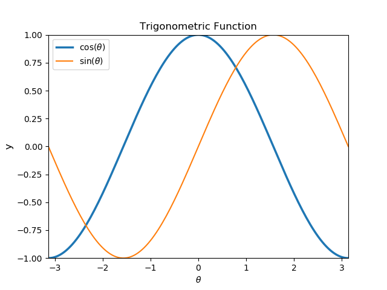

```python
plt.plot(theta, c, lw = 2.5, label= r'cos($\theta$)')
plt.plot(theta, s, label= r'sin($\theta$)')
```

```python
plt.xlim(-np.pi,np.pi)    # set the x limit. Same with the xrange keyward in IDL plot processor
```

```
(-3.141592653589793, 3.141592653589793)
```

```python
plt.ylim(-1,1)
```

```
(-1, 1)
```

```python
plt.title('Trigonometric Function')
plt.xlabel(r'$\theta$')
plt.ylabel('y', fontsize=12)
plt.legend()            # Insert the legendary box, and automatically locate the appropriate postion if there is now keyward.
```

```python
plt.legend(loc=1)
```

```python
plt.tight_layout()
```

```python
plt.savefig(r'D:\Juhyeong\fisspy-tutorials\tutorials\tri_fun.png')
```

```python
plt.savefig(r'D:\Juhyeong\fisspy-tutorials\tutorials\tri_fun.png')
```

Let's check the plot keywards.

```python
plt.plot?
```

**Exercise 5) Plot the tan function in red dashed line in $\theta$ range from $-\frac{2\pi}{5}$ to $\frac{2\pi}{5}$, and insert the legendary.**

Subplot, inset plot, tick, imshow & colorbar, contour

## 3.2. Subplots

Before we start this section, we change the plot setting. First we change the tick direction.

```python
plt.rc('xtick', direction='in')
plt.rc('ytick', direction='in')
plt.rc('xtick.minor',visible=True)
plt.rc('ytick.minor',visible=True)
```

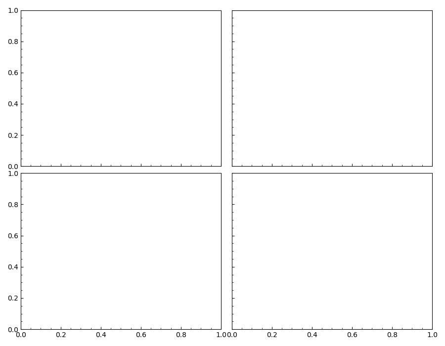

```python
fig, ax = plt.subplots(2, 2, sharex= True, sharey= True, figsize=(9,7))
```

```python
fig.tight_layout(h_pad=0,w_pad=0)
```

```python
plt.xticks([-np.pi,-0.5*np.pi,0,0.5*np.pi,np.pi],[r'$-\pi$',r'$-\frac{\pi}{2}$',0,r'$\frac{\pi}{2}$',r'$\pi$'])a
```

[output not shown]